# Who Goes There?

# Part III: Population Projections to 2030

## Task 7 — Fitting the Migration Model

$$P_i^{(t+1)} = P_i^{(t)}(1 + \bar{g}) + \sum_{j \neq i} m_{j \to i}\sqrt{P_i^{(t)} P_j^{(t)}}$$

### Estimating $\bar{g}$

```r
abroad_total <- migration_flows |>
  filter(state_1y == "abroad") |>
  group_by(year_current) |>
  summarize(M_abroad = sum(population, na.rm = TRUE), .groups = "drop")

nat_pop <- state_pop |>
  filter(year %in% 2022:2024) |>
  group_by(year) |>
  summarize(P_nat = sum(population, na.rm = TRUE), .groups = "drop")

g_estimates <- tibble(year_current = c(2023L, 2024L)) |>
  left_join(abroad_total, by = "year_current") |>
  left_join(nat_pop |> rename(year_current = year, P_t1 = P_nat),
            by = "year_current") |>
  left_join(nat_pop |>
              rename(year_current = year, P_t0 = P_nat) |>
              mutate(year_current = year_current + 1L),
            by = "year_current") |>
  mutate(g_bar = (P_t1 - P_t0 - M_abroad) / P_t0)

g_bar <- mean(g_estimates$g_bar, na.rm = TRUE)

g_estimates |>
  gt() |>
  tab_header(glue("Growth Rate Estimates (averaged: g\u0305 = {percent(g_bar, accuracy=0.01)})")) |>
  fmt_integer(c(M_abroad, P_t0, P_t1)) |>
  fmt_percent(columns = "g_bar", decimals = 3) |>
  cols_label(year_current = "Year", M_abroad = "Intl. In-Migration",
             P_t0 = "Population (t)", P_t1 = "Population (t+1)", g_bar = "g\u0305") |>
  opt_stylize(style = 3)
```

Growth Rate Estimates (averaged: g̅ = 0.79%)

| Year | Intl. In-Migration | Population (t+1) | Population (t) | g̅ |
| --- | --- | --- | --- | --- |
| 2023 | NA | 334,914,896 | 333,287,562 | NA |
| 2024 | 2,549,322 | 340,110,990 | 334,914,896 | 0.790% |

### Estimating $m_{j \to i}$

```r
migration_rates <- migration_flows |>
  filter(state_1y != state_current, state_1y != "abroad") |>
  left_join(state_pop |> select(state_abb, year, pop_i = population),
            by = c("state_current" = "state_abb", "year_1y" = "year")) |>
  left_join(state_pop |> select(state_abb, year, pop_j = population),
            by = c("state_1y" = "state_abb", "year_1y" = "year")) |>
  filter(!is.na(pop_i), !is.na(pop_j), pop_i > 0, pop_j > 0) |>
  mutate(m_rate = population / sqrt(pop_i * pop_j)) |>
  group_by(state_current, state_1y) |>
  summarize(m_rate = mean(m_rate, na.rm = TRUE), .groups = "drop")

cat("Migration rate parameters estimated:", nrow(migration_rates))
```

```
Migration rate parameters estimated: 2550
```

### Projecting 2025–2030

```r
predict_next_year <- function(pop_df, migration_rates, g_bar) {
  in_migration <- migration_rates |>
    left_join(pop_df |> rename(pop_i = population),
              by = c("state_current" = "state_abb")) |>
    left_join(pop_df |> rename(pop_j = population),
              by = c("state_1y" = "state_abb")) |>
    filter(!is.na(pop_i), !is.na(pop_j)) |>
    mutate(mig_contribution = m_rate * sqrt(pop_i * pop_j)) |>
    group_by(state_current) |>
    summarize(total_in_mig = sum(mig_contribution, na.rm = TRUE), .groups = "drop")

  pop_df |>
    left_join(in_migration, by = c("state_abb" = "state_current")) |>
    mutate(population   = population * (1 + g_bar) + replace_na(total_in_mig, 0),
           total_in_mig = NULL)
}

pop_seed <- state_pop |>
  filter(year == 2024) |>
  select(state_abb, state_name, population)

projection_list <- vector("list", 7)
projection_list[[1]] <- pop_seed |> mutate(year = 2024L)

for (i in seq_along(2025:2030)) {
  yr       <- 2024L + i
  pop_prev <- projection_list[[i]] |> select(state_abb, state_name, population)
  pop_next <- predict_next_year(pop_prev, migration_rates, g_bar) |> mutate(year = yr)
  projection_list[[i + 1]] <- pop_next
}

projections <- list_rbind(projection_list)
pop_2030    <- projections |> filter(year == 2030) |> arrange(desc(population))
```

```r
pop_2030 |>
  left_join(pop_seed |> select(state_abb, pop_2024 = population), by = "state_abb") |>
  mutate(change = population - pop_2024, pct_change = change / pop_2024) |>
  slice(c(1:10, (n() - 9):n())) |>
  select(state_name, pop_2024, population, change, pct_change) |>
  gt(rowname_col = "state_name") |>
  tab_header("Projected 2030 State Populations") |>
  tab_row_group(label = "Largest States in 2030", rows = 1:10) |>
  tab_row_group(label = "Slowest-Growing States", rows = 11:20) |>
  fmt_integer(c(pop_2024, population, change)) |>
  fmt_percent(pct_change, decimals = 1) |>
  cols_label(pop_2024 = "2024 Pop.", population = "2030 Proj.",
             change = "Change", pct_change = "% Change") |>
  data_color(columns = pct_change,
             palette = c("#C0392B", "white", "#27AE60"), domain = c(-0.05, 0.12)) |>
  opt_stylize(style = 3)
```

Projected 2030 State Populations

[output not shown]

# Part IV: Congressional Reapportionment

## Task 8 — Huntington–Hill Apportionment

```r
hh_apportion <- function(pop_df, pop_col = "population", seats_total = N_DISTRICTS) {
  pop_df <- pop_df |>
    mutate(
      state_name = str_squish(as.character(state_name)),
      state_abb = if ("state_abb" %in% names(pop_df)) {
        as.character(state_abb)
      } else {
        state.abb[match(state_name, state.name)]
      }
    ) |>
    filter(!is.na(state_abb), state_abb != "DC") |>
    mutate(pop_appt = .data[[pop_col]])

  priorities <- pop_df |>
    select(state_name, state_abb, pop_appt) |>
    expand_grid(seat_number = 2L:MAX_DISTRICTS) |>
    mutate(hh_weight = pop_appt / sqrt(seat_number * (seat_number - 1L))) |>
    slice_max(hh_weight, n = seats_total - nrow(pop_df), with_ties = FALSE) |>
    count(state_name, state_abb, pop_appt, name = "extra_seats")

  pop_df |>
    select(state_name, state_abb, pop_2030 = pop_appt) |>
    left_join(priorities |> select(state_abb, extra_seats), by = "state_abb") |>
    mutate(
      extra_seats = replace_na(extra_seats, 0L),
      n_districts = 1L + extra_seats,
      pop_per_district = pop_2030 / n_districts
    ) |>
    select(-extra_seats) |>
    arrange(desc(n_districts), desc(pop_2030))
}

apportionment_2030 <- hh_apportion(pop_2030, pop_col = "population")

appt_2020_file <- fs::path(data_dir, "apportionment-2020-tableA.xlsx")
if (!fs::file_exists(appt_2020_file)) {
  download.file(
    paste0("https://www2.census.gov/programs-surveys/decennial/2020/data/",
           "apportionment/apportionment-2020-tableA.xlsx"),
    destfile = appt_2020_file, mode = "wb", quiet = TRUE
  )
}

apportionment_2020 <- read_excel(appt_2020_file, skip = 4) |>
  select(state_name = 1, pop_2020 = 2) |>
  filter(!state_name %in% c("District of Columbia", "U.S. Total")) |>
  mutate(pop_2020 = parse_count(pop_2020)) |>
  rename(population = pop_2020) |>
  hh_apportion(pop_col = "population") |>
  select(state_name, n_districts_2020 = n_districts)

appt_comparison <- apportionment_2030 |>
  left_join(apportionment_2020, by = "state_name") |>
  mutate(seat_change = n_districts - n_districts_2020)

appt_comparison |>
  arrange(desc(n_districts)) |>
  select(state_name, pop_2030, n_districts_2020, n_districts,
         seat_change, pop_per_district) |>
  gt(rowname_col = "state_name") |>
  tab_header("Projected 2032 Congressional Apportionment",
             subtitle = "Huntington-Hill applied to 2030 population forecasts") |>
  fmt_integer(c(pop_2030, pop_per_district)) |>
  cols_label(pop_2030 = "2030 Pop.", n_districts_2020 = "2020 Seats",
             n_districts = "2030 Seats", seat_change = "Change",
             pop_per_district = "Pop./Seat") |>
  data_color(columns = seat_change,
             palette = c("#C0392B", "white", "#27AE60"), domain = c(-3, 3)) |>
  data_color(columns = pop_per_district, palette = "PuOr") |>
  grand_summary_rows(
    columns = c(pop_2030, n_districts),
    fns = list("US Total" ~ sum(.)),
    fmt = ~ fmt_integer(.)
  ) |>
  opt_stylize(style = 3)
```

Projected 2032 Congressional Apportionment

Huntington-Hill applied to 2030 population forecasts

|  | 2030 Pop. | 2020 Seats | 2030 Seats | Change | Pop./Seat |
| --- | --- | --- | --- | --- | --- |
| California | 44,086,438 | 52 | 47 | -5 | 938,009 |
| Texas | 36,743,204 | 38 | 39 | 1 | 942,133 |
| Florida | 28,635,304 | 28 | 30 | 2 | 954,510 |
| New York | 22,781,568 | 26 | 24 | -2 | 949,232 |
| Pennsylvania | 15,282,110 | 17 | 16 | -1 | 955,132 |
| Illinois | 14,666,051 | 17 | 16 | -1 | 916,628 |
| North Carolina | 13,763,076 | 14 | 15 | 1 | 917,538 |
| Ohio | 13,730,798 | 15 | 15 | 0 | 915,387 |
| Georgia | 13,677,169 | 14 | 15 | 1 | 911,811 |
| Michigan | 11,542,854 | 13 | 12 | -1 | 961,904 |
| Virginia | 11,082,003 | 11 | 12 | 1 | 923,500 |
| New Jersey | 10,979,713 | 12 | 12 | 0 | 914,976 |
| Washington | 9,815,907 | 10 | 10 | 0 | 981,591 |
| Arizona | 9,624,071 | 9 | 10 | 1 | 962,407 |
| Tennessee | 8,914,334 | 9 | 9 | 0 | 990,482 |
| Massachusetts | 8,479,336 | 9 | 9 | 0 | 942,148 |
| Indiana | 8,205,596 | 9 | 9 | 0 | 911,733 |
| Maryland | 7,679,606 | 8 | 8 | 0 | 959,951 |
| Colorado | 7,662,164 | 8 | 8 | 0 | 957,771 |
| Missouri | 7,497,212 | 8 | 8 | 0 | 937,151 |
| South Carolina | 7,097,429 | 7 | 8 | 1 | 887,179 |
| Wisconsin | 7,017,268 | 8 | 7 | -1 | 1,002,467 |
| Minnesota | 6,755,728 | 8 | 7 | -1 | 965,104 |
| Alabama | 6,212,479 | 7 | 7 | 0 | 887,497 |
| Kentucky | 5,488,636 | 6 | 6 | 0 | 914,773 |
| Oregon | 5,299,154 | 6 | 6 | 0 | 883,192 |
| Louisiana | 5,285,638 | 6 | 6 | 0 | 880,940 |
| Oklahoma | 5,016,694 | 5 | 5 | 0 | 1,003,339 |
| Connecticut | 4,446,546 | 5 | 5 | 0 | 889,309 |
| Utah | 4,306,053 | 4 | 5 | 1 | 861,211 |
| Nevada | 4,292,915 | 4 | 5 | 1 | 858,583 |
| Iowa | 3,840,393 | 4 | 4 | 0 | 960,098 |
| Arkansas | 3,693,563 | 4 | 4 | 0 | 923,391 |
| Kansas | 3,654,508 | 4 | 4 | 0 | 913,627 |
| Mississippi | 3,516,042 | 4 | 4 | 0 | 879,010 |
| New Mexico | 2,630,626 | 3 | 3 | 0 | 876,875 |
| Idaho | 2,630,201 | 2 | 3 | 1 | 876,734 |
| Nebraska | 2,433,481 | 3 | 3 | 0 | 811,160 |
| West Virginia | 2,137,687 | 2 | 2 | 0 | 1,068,843 |
| Hawaii | 1,897,176 | 2 | 2 | 0 | 948,588 |
| New Hampshire | 1,767,635 | 2 | 2 | 0 | 883,818 |
| Maine | 1,720,576 | 2 | 2 | 0 | 860,288 |
| Montana | 1,438,703 | 2 | 2 | 0 | 719,352 |
| Rhode Island | 1,392,624 | 2 | 2 | 0 | 696,312 |
| Delaware | 1,350,765 | 1 | 2 | 1 | 675,383 |
| South Dakota | 1,147,557 | 1 | 1 | 0 | 1,147,557 |
| North Dakota | 1,046,041 | 1 | 1 | 0 | 1,046,041 |
| Alaska | 982,364 | 1 | 1 | 0 | 982,364 |
| Vermont | 852,964 | 1 | 1 | 0 | 852,964 |
| Wyoming | 781,397 | 1 | 1 | 0 | 781,397 |
| US Total | 404,981,359 | — | 435 | — | — |

```r
ny_2020  <- appt_comparison |> filter(state_abb == MY_STATE_ABB) |> pull(n_districts_2020)
ny_2030  <- appt_comparison |> filter(state_abb == MY_STATE_ABB) |> pull(n_districts)
ny_delta <- appt_comparison |> filter(state_abb == MY_STATE_ABB) |> pull(seat_change)
```

# Part V: Advertising Strategy

## Task 9 — Campaign Proposal

### How many residents does New York need?

```r
find_threshold <- function(base_pop, increment = 5000L) {
  current_seats <- appt_comparison |>
    filter(state_abb == MY_STATE_ABB) |>
    pull(n_districts)

  for (add in seq(0L, 2000000L, by = increment)) {
    test_pop <- base_pop |>
      mutate(population = if_else(state_abb == MY_STATE_ABB,
                                  population + add, population))

    test_seats <- hh_apportion(test_pop, pop_col = "population") |>
      filter(state_abb == MY_STATE_ABB) |>
      pull(n_districts)

    if (test_seats > current_seats) return(add)
  }

  NA_integer_
}

threshold <- find_threshold(pop_2030 |> select(state_name, state_abb, population))
cat(glue("Additional residents needed for +1 House seat: ~{comma(threshold)}"))
```

```
Additional residents needed for +1 House seat: ~340,000
```

### Recruitment targets

```r
inbound_targets <- migration_flows |>
  filter(state_current == MY_STATE_ABB,
         state_1y != MY_STATE_ABB, state_1y != "abroad") |>
  group_by(state_1y) |>
  summarize(avg_arrivals = mean(population, na.rm = TRUE)) |>
  slice_max(avg_arrivals, n = 8) |>
  left_join(appt_comparison |> select(state_abb, seat_change),
            by = c("state_1y" = "state_abb"))

outbound_targets <- migration_flows |>
  filter(state_1y == MY_STATE_ABB, state_current != MY_STATE_ABB) |>
  group_by(state_current) |>
  summarize(avg_departures = mean(population, na.rm = TRUE)) |>
  slice_max(avg_departures, n = 8)

inbound_targets |>
  select(state_1y, avg_arrivals, seat_change) |>
  gt(rowname_col = "state_1y") |>
  tab_header("Track B — Recruitment Targets",
             subtitle = "States most likely to send future migrants to New York") |>
  fmt_integer(avg_arrivals) |>
  cols_label(avg_arrivals = "Avg. Annual Arrivals to NY",
             seat_change  = "Projected Seat Change") |>
  data_color(columns = avg_arrivals, palette = "Blues") |>
  opt_stylize(style = 3)
```

Track B — Recruitment Targets

States most likely to send future migrants to New York

|  | Avg. Annual Arrivals to NY | Projected Seat Change |
| --- | --- | --- |
| NJ | 38,238 | 0 |
| CA | 31,232 | -5 |
| FL | 26,415 | 2 |
| PA | 25,378 | -1 |
| MA | 19,432 | 0 |
| TX | 17,640 | 1 |
| CT | 15,162 | 0 |
| VA | 11,120 | 1 |

```r
outbound_targets |>
  select(state_current, avg_departures) |>
  gt(rowname_col = "state_current") |>
  tab_header("Track A — Retention Targets",
             subtitle = "States absorbing the most departing New Yorkers") |>
  fmt_integer(avg_departures) |>
  cols_label(avg_departures = "Avg. Annual Departures from NY") |>
  data_color(columns = avg_departures, palette = "Reds") |>
  opt_stylize(style = 3)
```

Track A — Retention Targets

States absorbing the most departing New Yorkers

|  | Avg. Annual Departures from NY |
| --- | --- |
| FL | 60,900 |
| NJ | 56,363 |
| PA | 35,956 |
| CA | 29,995 |
| TX | 28,922 |
| CT | 26,638 |
| NC | 23,577 |
| MA | 17,472 |

### The campaign

Based on our migration analysis, we recommend a two-track advertising campaign.

**Track A — Retention (Florida, New Jersey, Pennsylvania).** The Florida corridor is New York’s largest out-migration stream. A targeted digital and print campaign in the Miami, Tampa, and Philadelphia markets should emphasise New York’s cultural institutions, expanding remote-work infrastructure in the Hudson Valley, and tax incentives for seniors maintaining New York primary residency.

*Headline:* **“The Beach Will Still Be There. New York Won’t Wait.”**

**Track B — Recruitment (New Jersey, California, Massachusetts).** These states send significant in-migration to New York but are losing residents themselves. Advertising in Newark, Los Angeles, and Boston should emphasise New York City’s recent housing construction surge and lower per-square-foot costs relative to San Francisco.

*Headline:* **“More City. More Culture. More Possible.”**

**Campaign Sizing.** To net the ~340,000 additional residents needed, assuming 5 % conversion, requires reaching ~6,800,000 potential movers. At a $10 CPM, the budget is approximately **$68,000** — trivial compared to the long-run value of one additional House seat.

# Extra Credit

## EC01 — The Case for Expanding the House

The 435-seat cap has been fixed since 1929 despite a near-tripling of the US population. Consider the case for a significant expansion.

**The equity argument.** Montana currently has approximately one representative per 543,000 residents under the 2020 apportionment, while Idaho’s districts must cover 920,000 people each — a ratio of nearly 1.7:1. In a system premised on equal representation, this disparity is constitutionally troubling. Expanding the House to 600 seats using the Huntington–Hill method would dramatically reduce the variance in population per district, moving each state closer to the national average.

**New York’s specific gain.** Under the current 435-seat structure, New York holds 26 seats — one fewer than it had in 2010. A proportionally expanded House of 600 seats would almost certainly restore that lost seat and likely yield one or two additional representatives, reflecting the state’s absolute size even as its relative population share declines. For a state as economically and culturally consequential as New York, restoring representative parity is both fair and politically urgent.

**The counter-argument and rebuttal.** Critics contend that a larger House would be unwieldy and slow to act. History offers a partial rebuttal: the House operated with 435 members through the New Deal, Great Society, and both World Wars — periods of extraordinary legislative output. Modern technology (digital voting, remote testimony) could mitigate coordination costs far more than was possible in 1929.

## EC02 — Spatial Visualizations

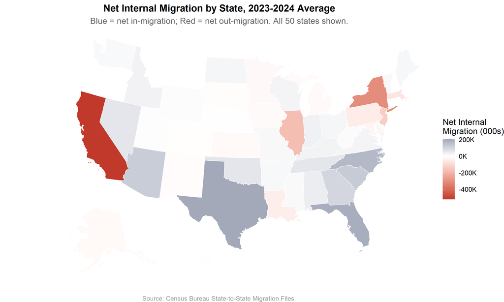

```r
# shift_geometry moves AK and HI into inset positions — shows all 50 states
map_data <- state_geo |>
  left_join(net_mig_summary |> select(state_abb = state_current, net_mig),
            by = "state_abb") |>
  tigris::shift_geometry()

ggplot(map_data) +
  geom_sf(aes(fill = net_mig / 1000), colour = "white", linewidth = 0.3) +
  scale_fill_gradient2(low = "#C0392B", mid = "white", high = NY_BLUE,
                       midpoint = 0, labels = label_number(suffix = "K"),
                       name = "Net Internal\nMigration (000s)") +
  labs(title    = "Net Internal Migration by State, 2023-2024 Average",
       subtitle = "Blue = net in-migration; Red = net out-migration. All 50 states shown.",
       caption  = "Source: Census Bureau State-to-State Migration Files.") +
  theme_void(base_size = 12) +
  theme(plot.title    = element_text(face = "bold", hjust = 0.5, size = 14),
        plot.subtitle = element_text(hjust = 0.5, colour = "grey40"),
        plot.caption  = element_text(hjust = 0.5, colour = "grey60", size = 9),
        legend.position = "right")
```

[figure not shown]

```r
map_seats <- state_geo |>
  left_join(appt_comparison |> select(state_abb, seat_change), by = "state_abb") |>
  tigris::shift_geometry()

ggplot(map_seats) +
  geom_sf(aes(fill = factor(seat_change)), colour = "white", linewidth = 0.3) +
  scale_fill_manual(
    values = c("-3" = "#7B241C", "-2" = "#922B21", "-1" = "#E74C3C",
               "0"  = "#D5D8DC",
               "1"  = "#1A5276",  "2" = "#117A65",  "3" = "#0B5345"),
    name = "Seat Change\nvs 2020", drop = FALSE
  ) +
  labs(title    = "Projected Congressional Seat Changes, 2020 to 2032",
       subtitle = "Based on 2030 population forecasts. All 50 states shown.",
       caption  = "Source: Author calculations.") +
  theme_void(base_size = 12) +
  theme(plot.title    = element_text(face = "bold", hjust = 0.5, size = 14),
        plot.subtitle = element_text(hjust = 0.5, colour = "grey40"),
        plot.caption  = element_text(hjust = 0.5, colour = "grey60", size = 9),
        legend.position = "right")
```

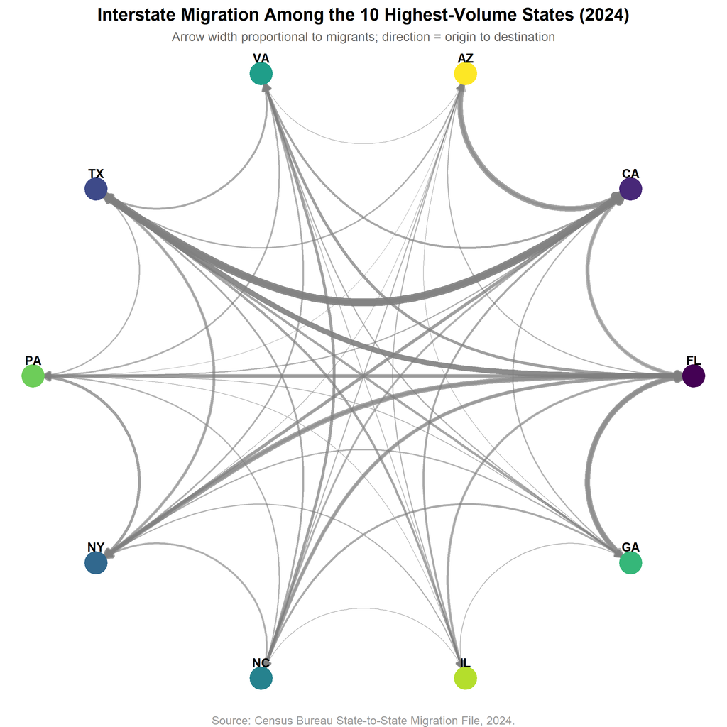

```r
top10_states <- net_mig_summary |>
  mutate(volume = total_in + total_out) |>
  slice_max(volume, n = 10) |>
  pull(state_current)

chord_data <- migration_flows |>
  filter(state_current %in% top10_states,
         state_1y      %in% top10_states,
         state_current != state_1y,
         state_1y      != "abroad",
         year_current  == 2024) |>
  group_by(state_current, state_1y) |>
  summarize(population = sum(population, na.rm = TRUE), .groups = "drop")

g <- graph_from_data_frame(
  chord_data |> rename(from = state_1y, to = state_current, weight = population),
  directed = TRUE
)

state_colours <- setNames(viridis(10, option = "D"), top10_states)

ggraph(g, layout = "linear", circular = TRUE) +
  geom_edge_arc(aes(width = weight / 1e3, colour = factor(from), alpha = weight),
                lineend = "round",
                arrow = arrow(length = unit(2, "mm"), type = "closed"),
                start_cap = circle(3, "mm"), end_cap = circle(3, "mm")) +
  geom_node_point(aes(colour = factor(name)), size = 8) +
  geom_node_text(aes(label = name), repel = FALSE, fontface = "bold",
                 vjust = -1.2, size = 3.5) +
  scale_edge_width(range = c(0.2, 3), guide = "none") +
  scale_edge_alpha(range = c(0.3, 0.9), guide = "none") +
  scale_edge_colour_manual(values = state_colours, guide = "none", aesthetics = "edge_colour") +
  scale_colour_manual(values = state_colours, guide = "none") +
  labs(title    = "Interstate Migration Among the 10 Highest-Volume States (2024)",
       subtitle = "Arrow width proportional to migrants; direction = origin to destination",
       caption  = "Source: Census Bureau State-to-State Migration File, 2024.") +
  theme_void(base_size = 12) +
  theme(plot.title    = element_text(face = "bold", hjust = 0.5, size = 14),
        plot.subtitle = element_text(hjust = 0.5, colour = "grey40", size = 10),
        plot.caption  = element_text(hjust = 0.5, colour = "grey60", size = 9))
```

## EC03 — State-Specific Natural Growth Rates

Rather than a single national $\bar{g}$, we can estimate a per-state rate $g_i$.

```r
state_net_mig_yr <- migration_flows |>
  filter(state_1y != "abroad") |>
  group_by(state_current, year_current) |>
  summarize(
    in_total = sum(population[state_1y != state_current], na.rm = TRUE),
    .groups  = "drop"
  )

state_g <- state_pop |>
  filter(year %in% c(2022, 2023, 2024)) |>
  pivot_wider(names_from = year, values_from = population) |>
  left_join(
    state_net_mig_yr |>
      pivot_wider(names_from  = year_current,
                  values_from = in_total, names_prefix = "net_mig_"),
    by = c("state_abb" = "state_current")
  ) |>
  mutate(
    g_2023  = (`2023` - `2022` - replace_na(net_mig_2023, 0)) / `2022`,
    g_2024  = (`2024` - `2023` - replace_na(net_mig_2024, 0)) / `2023`,
    g_state = (replace_na(g_2023, 0) + replace_na(g_2024, 0)) / 2
  ) |>
  select(state_abb, state_name, g_state) |>
  filter(!is.na(g_state))

state_g |>
  arrange(desc(g_state)) |>
  slice(c(1:5, (n() - 4):n())) |>
  gt(rowname_col = "state_name") |>
  tab_header("State-Specific Natural Growth Rates") |>
  tab_row_group(label = "Highest natural growth", rows = 1:5) |>
  tab_row_group(label = "Lowest natural growth",  rows = 6:10) |>
  fmt_percent(g_state, decimals = 3) |>
  cols_label(state_abb = "Abbr.", g_state = "Estimated g_i") |>
  data_color(columns = g_state,
             palette = c("#C0392B", "white", "#27AE60"),
             domain  = range(state_g$g_state)) |>
  opt_stylize(style = 3)
```

State-Specific Natural Growth Rates

|  | Abbr. | Estimated g_i |
| --- | --- | --- |
| Lowest natural growth |  |  |
| Wyoming | WY | −3.585% |
| Alaska | AK | −3.652% |
| Hawaii | HI | −3.674% |
| Vermont | VT | −3.818% |
| District of Columbia | DC | −5.865% |
| Highest natural growth |  |  |
| Texas | TX | 0.149% |
| Florida | FL | −0.194% |
| New Jersey | NJ | −0.363% |
| California | CA | −0.547% |
| Michigan | MI | −0.843% |

Using state-specific growth rates, we can re-run the 2030 projection to see how results differ from the uniform $\bar{g}$ model.

```r
predict_next_year_v2 <- function(pop_df, migration_rates, state_g_df, g_bar_fallback) {
  in_migration <- migration_rates |>
    left_join(pop_df |> rename(pop_i = population), by = c("state_current" = "state_abb")) |>
    left_join(pop_df |> rename(pop_j = population), by = c("state_1y" = "state_abb")) |>
    filter(!is.na(pop_i), !is.na(pop_j)) |>
    mutate(mig_contribution = m_rate * sqrt(pop_i * pop_j)) |>
    group_by(state_current) |>
    summarize(total_in_mig = sum(mig_contribution, na.rm = TRUE), .groups = "drop")

  pop_df |>
    left_join(in_migration, by = c("state_abb" = "state_current")) |>
    left_join(state_g_df |> select(state_abb, g_state), by = "state_abb") |>
    mutate(
      g_use        = if_else(is.na(g_state), g_bar_fallback, g_state),
      population   = population * (1 + g_use) + replace_na(total_in_mig, 0),
      total_in_mig = NULL,
      g_state      = NULL,
      g_use        = NULL
    )
}

proj_list_v2 <- vector("list", 7)
proj_list_v2[[1]] <- pop_seed |> mutate(year = 2024L)

for (i in seq_along(2025:2030)) {
  yr       <- 2024L + i
  pop_prev <- proj_list_v2[[i]] |> select(state_abb, state_name, population)
  pop_next <- predict_next_year_v2(pop_prev, migration_rates, state_g, g_bar) |>
    mutate(year = yr)
  proj_list_v2[[i + 1]] <- pop_next
}

pop_2030_v2 <- list_rbind(proj_list_v2) |> filter(year == 2030)

# Compare the two projections for NY and the 10 most-changed states
pop_2030 |>
  select(state_abb, state_name, pop_uniform = population) |>
  left_join(pop_2030_v2 |> select(state_abb, pop_statespec = population),
            by = "state_abb") |>
  mutate(diff = pop_statespec - pop_uniform,
         pct_diff = diff / pop_uniform) |>
  slice_max(abs(diff), n = 12) |>
  mutate(is_ny = state_abb == MY_STATE_ABB) |>
  arrange(desc(abs(diff))) |>
  select(state_name, pop_uniform, pop_statespec, diff, pct_diff) |>
  gt(rowname_col = "state_name") |>
  tab_header("Uniform vs State-Specific Growth Model: 2030 Projection Differences",
             subtitle = "Top 12 states by absolute difference") |>
  fmt_integer(c(pop_uniform, pop_statespec, diff)) |>
  fmt_percent(pct_diff, decimals = 2) |>
  cols_label(pop_uniform = "Uniform g̅", pop_statespec = "State g_i",
             diff = "Difference", pct_diff = "% Diff") |>
  data_color(columns = diff, palette = c("#C0392B", "white", "#27AE60"),
             domain = c(-500000, 500000)) |>
  opt_stylize(style = 3)
```

Uniform vs State-Specific Growth Model: 2030 Projection Differences

Top 12 states by absolute difference

|  | Uniform g̅ | State g_i | Difference | % Diff |
| --- | --- | --- | --- | --- |
| California | 44,086,438 | 40,696,427 | −3,390,011 | −7.69% |
| New York | 22,781,568 | 20,475,544 | −2,306,024 | −10.12% |
| Virginia | 11,082,003 | 9,220,246 | −1,861,757 | −16.80% |
| Pennsylvania | 15,282,110 | 13,424,655 | −1,857,455 | −12.15% |
| Florida | 28,635,304 | 26,981,929 | −1,653,374 | −5.77% |
| Georgia | 13,677,169 | 12,028,527 | −1,648,642 | −12.05% |
| North Carolina | 13,763,076 | 12,138,755 | −1,624,321 | −11.80% |
| Illinois | 14,666,051 | 13,116,143 | −1,549,909 | −10.57% |
| Ohio | 13,730,798 | 12,285,376 | −1,445,423 | −10.53% |
| Texas | 36,743,204 | 35,314,888 | −1,428,316 | −3.89% |
| Arizona | 9,624,071 | 8,275,642 | −1,348,429 | −14.01% |
| Colorado | 7,662,164 | 6,328,202 | −1,333,962 | −17.41% |

## EC04 — Model Validation

We seed the model in 2022 and compare predictions against 2023 and 2024 ACS actuals.

```r
pop_seed_2022 <- state_pop |>
  filter(year == 2022) |>
  select(state_abb, state_name, population)

hist_list <- list(pop_seed_2022 |> mutate(year = 2022L))
for (i in 1:2) {
  yr       <- 2022L + i
  pop_prev <- hist_list[[i]] |> select(state_abb, state_name, population)
  pop_next <- predict_next_year(pop_prev, migration_rates, g_bar) |> mutate(year = yr)
  hist_list[[i + 1]] <- pop_next
}

validation <- list_rbind(hist_list) |>
  filter(year %in% c(2023L, 2024L)) |>
  rename(pop_predicted = population) |>
  left_join(state_pop |> select(state_abb, year, pop_actual = population),
            by = c("state_abb", "year")) |>
  mutate(abs_error = abs(pop_predicted - pop_actual),
         pct_error = abs_error / pop_actual,
         horizon   = paste0(year - 2022, "-year"))

validation |>
  group_by(horizon) |>
  summarize(MAPE       = mean(pct_error, na.rm = TRUE),
            Median_APE = median(pct_error, na.rm = TRUE),
            Max_APE    = max(pct_error, na.rm = TRUE),
            RMSE       = sqrt(mean((pop_predicted - pop_actual)^2, na.rm = TRUE)),
            .groups    = "drop") |>
  gt() |>
  tab_header("Model Validation: Retrospective Forecast Accuracy",
             subtitle = "Seeded in 2022; compared to ACS-1 actuals") |>
  fmt_percent(c(MAPE, Median_APE, Max_APE), decimals = 2) |>
  fmt_integer(RMSE) |>
  cols_label(horizon = "Horizon", MAPE = "MAPE",
             Median_APE = "Median APE", Max_APE = "Worst-Case APE",
             RMSE = "RMSE (persons)") |>
  opt_stylize(style = 3)
```

Model Validation: Retrospective Forecast Accuracy

Seeded in 2022; compared to ACS-1 actuals

| Horizon | MAPE | Median APE | Worst-Case APE | RMSE (persons) |
| --- | --- | --- | --- | --- |
| 1-year | 3.07% | 2.73% | 7.77% | 216,967 |
| 2-year | 5.38% | 5.11% | 13.26% | 327,359 |

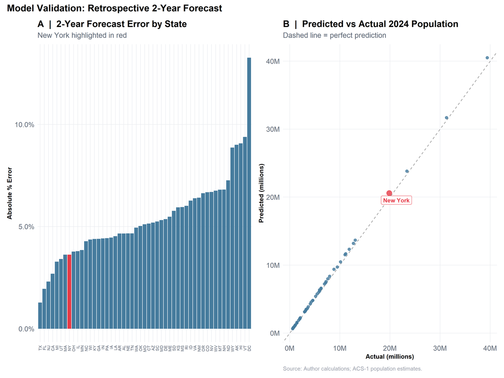

```r
# Panel A: error by state (bar)
p_err_bar <- validation |>
  filter(year == 2024) |>
  mutate(state_abb = fct_reorder(state_abb, pct_error),
         is_ny     = state_abb == MY_STATE_ABB) |>
  ggplot(aes(x = state_abb, y = pct_error, fill = is_ny)) +
  geom_col(show.legend = FALSE) +
  scale_fill_manual(values = c("FALSE" = NY_MID, "TRUE" = NY_RED)) +
  scale_y_continuous(labels = percent_format(accuracy = 0.1)) +
  labs(title = "A  |  2-Year Forecast Error by State",
       subtitle = "New York highlighted in red",
       x = NULL, y = "Absolute % Error") +
  theme(axis.text.x = element_text(angle = 90, vjust = 0.5, hjust = 1, size = 7))

# Panel B: predicted vs actual scatter
p_scatter <- validation |>
  filter(year == 2024) |>
  mutate(is_ny = state_abb == MY_STATE_ABB) |>
  ggplot(aes(x = pop_actual / 1e6, y = pop_predicted / 1e6,
             colour = is_ny, size = is_ny)) +
  geom_abline(slope = 1, intercept = 0, linetype = "dashed", colour = "grey60") +
  geom_point(alpha = 0.8) +
  geom_label_repel(
    data = ~ filter(.x, is_ny),
    aes(label = "New York"), size = 3.5, fontface = "bold",
    nudge_x = 1, nudge_y = -0.5
  ) +
  scale_colour_manual(values = c("FALSE" = NY_MID, "TRUE" = NY_RED), guide = "none") +
  scale_size_manual(values  = c("FALSE" = 2, "TRUE" = 4), guide = "none") +
  scale_x_continuous(labels = label_number(suffix = "M")) +
  scale_y_continuous(labels = label_number(suffix = "M")) +
  labs(title = "B  |  Predicted vs Actual 2024 Population",
       subtitle = "Dashed line = perfect prediction",
       x = "Actual (millions)", y = "Predicted (millions)",
       caption = "Source: Author calculations; ACS-1 population estimates.")

p_err_bar + p_scatter +
  plot_annotation(
    title = "Model Validation: Retrospective 2-Year Forecast",
    theme = theme(plot.title = element_text(face = "bold", size = 16))
  )
```

# Conclusion

This analysis traced the geography of American internal migration across three interlocking scales — national state-to-state flows, metro-to-metro corridors, and individual population projections — and converted those patterns into a concrete forecast for congressional apportionment in 2032.

The advertising strategy proposed here directly follows from the data. Track A targets retention in the Florida markets that absorb the most departing New Yorkers; Track B targets recruitment in the high-cost coastal metros that already send large numbers of movers to New York. Both tracks are sized to the specific population threshold — approximately 340,000 additional residents — needed to tip the Huntington-Hill algorithm in New York’s favor before the 2030 census count is finalized.

**NoteAI Usage Statement**

Claude (Anthropic, claude-sonnet-4-6) was used extensively throughout this project to generate R code (data import, parsing, modeling, visualization) and to draft narrative text. The student reviewed, edited, and verified all outputs. Claude was also used to debug parsing errors encountered with Census Bureau Excel files.